# Motivación

Ya sabemos cómo crear un modelo muy sencillo de regresión, la regresión lineal. Es decir, dado un conjunto de datos etiquetados en el que la etiqueta es una variable continua, hemos visto cómo ajustar una recta de la mejor manera posible a los datos para predecir la etiqueta. Ahora vamos a enfrentarnos a otro problema central del apredizaje supervisado, a la clasificación.

## Clasificación

Recordamos que los problemas de clasificación pertenecen al aprendizaje supervisado, y en ellos la etiqueta que intentamos predecir mediante los atributos sólo puede tomar una cantidad finita de valores.

El ejemplo paradigmático de clasificación es un filtro de spam, pero también un ejemplo relevante sería la clasificación de tumores en cancerígeno, maligno y benigno.

\begin{align*} (x^{(1)}, y^{(1)}) & = (-0.13459237, 0)\\ (x^{(2)}, y^{(2)}) & = (-3.3015387, 0)\\ (x^{(3)}, y^{(3)}) & = (0.74481176, 0)\\ (x^{(4)}, y^{(4)}) & = (2.62434536, 1)\\ (x^{(5)}, y^{(5)}) & = (0.38824359, 1)\\ (x^{(6)}, y^{(6)}) & = (0.47182825, 1)\\ (x^{(7)}, y^{(7)}) & = (-0.07296862, 1) \end{align*}

Comenzamos visualizando los datos:

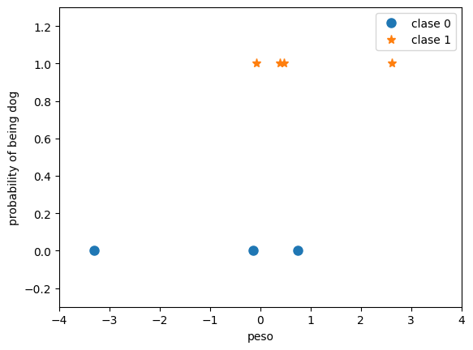

Lo que vamos a hacer es intentar adaptar a este contexto la solución que ya tenemos a otro problema, la regresión lineal.

**Tenemos dos obstáculos:**

1. El rango de nuestra función $f$ en la regresión lineal era todo $\mathbb{R}$, y aquí la variable $y$ sólo toma los valores $0$ y $1$.
2. Necesitamos adaptar nuestra función de coste.

# Intento naive

Como primer intento, podemos tomar este problema como si fuera una regresión y ajustar una recta a estos datos. Denotemos por $f(x)$ la función de que describe esta recta. Para determinar a qué clase pertenece cada punto, podemos fijar un umbral, por ejemplo $0,5$, y fijar que clasificamos como clase $1$ todos aquellos puntos tales que $f(x) \geq 0,5$ y como clase $0$ el resto.

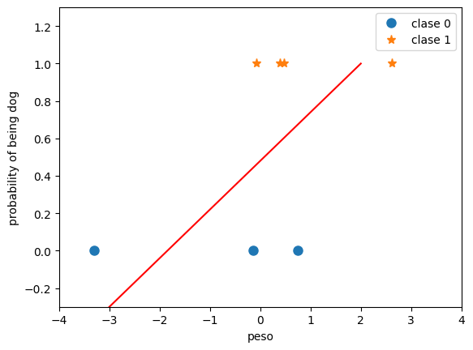

Vemos que el resultado no es muy bueno debido a que el rango de la recta es demasiado grande. Además, añadir algún ejemplo más con valores de $x$ mucho mayores o mucho menores, no sólo no aportaría, sino que desajustaría aún más la predicción.

Necesitamos pues una función $f(x)$ que, aunque devuelva más valores que sólo $0$ y $1$, al menos cumpla que $$0 \leq f(x) \leq 1.$$

# Regresión logística

Una de las funciones más sencillas que cumple esta condición es la **función sigmoide** o **función logística**.

## Forma de $f$

### Definición: función sigmoide

La función sigmoide $ \sigma$ es una función definida sobre todo $\mathbb{R}$ y que viene dada por $$ \sigma(z) = \frac{1}{1 + \exp^{-x}} .$$ Su rango de valores es el intervalo $(0,1)$.

[figure not shown]

Para ajustar la función sigmoide al dataset dado, lo más sencillo es componer con una función lineal: $$f(x) = \sigma( wx+b) = \frac{1}{1 + \exp^{-( wx+b)}}.$$

### Interpretación

Puesto que los valores de $f$ están entre $0$ y $1$, podemos interpretarlos como una probabilidad: $$f(x) = p (y = 1 | x).$$

Como vimos, la clase que predice $f$ será $1$ si esta probabilidad es igual o superior a $0.5$ y $0$ en el caso contrario Analicemos también cómo cuándo estamos por encima de este umbral: \begin{align*} f(x) \geq 0.5 & \Leftrightarrow \sigma(wx+b) \geq 0.5 \\ & \Leftrightarrow wx+b \geq 0 \end{align*} Vemos así que la frontera que separa una clase de la otra está determinada por $wx+b = 0$, que es un punto sobre la recta. Más adelante veremos que si tenemos dos variables $x_1$ y $x_2$ esta frontera estará determinada por una recta en el plano.

## Función de coste

Ya sabemos qué aspecto tiene la función que vamos a usar para problemas de clasificación, pero, como en el caso de la regresión lineal, tenemos que poder *cuantificar* cómo de bien estamos modelizando, para lo cual necesitamos una función de coste. Denotemos por $y$ la clase real de un punto y por $\hat{y} = f(x)$ su predicción. Dado un dataset con $N$ puntos, usamos superíndices para distinguirlos, $(x^{(1)}, y^{(1)}), \ldots, (x^{(N)}, y^{(N)})$. Existen varias opciones para la función de coste (dos clases):

1. **Error cuadrático (SE) o función de coste de Brier**: Como antes, podemos considerar el error de una predicción como $\left( \hat{y} - y \right)^2$, y tenemos la función de coste $$L_{\mathrm{SE}}(w,b) := \sum_{i=1}^N \left(\hat{y}^{(i)} - y^{(i)}\right)^2.$$
2. **Entropía cruzada binaria (BCE)**: $$L_{\mathrm{BCE}}(w,b) := - \sum_{i=1}^N \left( (1- y^{(i)}) \log(1- \hat{y}^{(i)}) + y^{(i)} \log (\hat{y}^{(i)}) \right).$$ Veamos un ejemplo con $N=1$. Si la clase real de nuestro punto es $1$, el error será $ - \log (\hat{y})$; aquí, cuanto más baja la probabilidad con la que decimos que el punto será de clase $1$, mayor es el error que cometemos. Sucede algo análogo con la otra clase. Es decir, que le entropía cruzada penaliza predicciones incorrectas hechas con mucha seguridad más que las incorrectas hechas con menos seguridad.

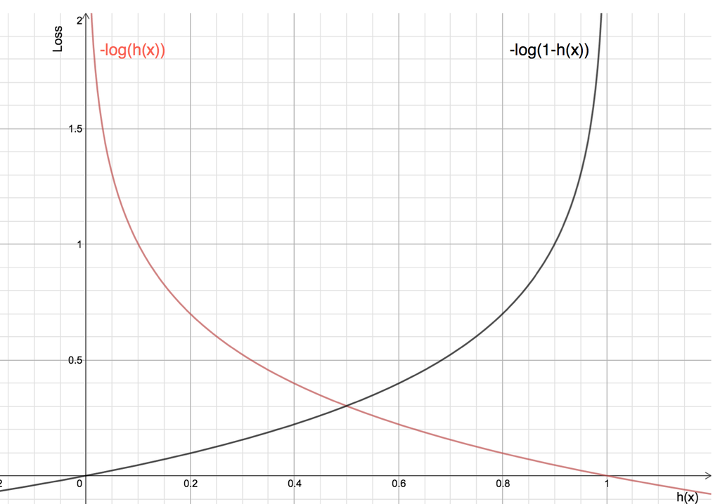

Veamos algunos ejemplos de funciones de esta forma y los errores asociados para ambas métricas:

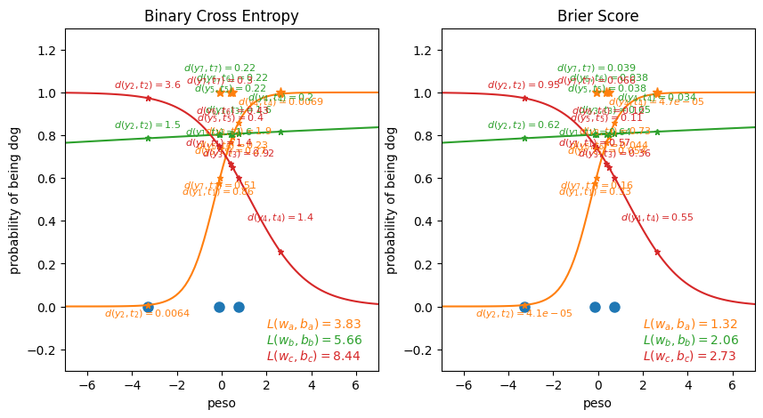

## Ejemplo: Valores de la función de coste con $b$ fijo

Veamos cómo cambian las rectas y el valor de la función de coste en nuestro ejemplo cuando variamos los parámetros. Para simplificar, variamos sólo $w$ y fijamos $b=0.5$.

[video not shown]

## Ejemplo: Valores de la función de coste variando $w$ y $b$

A continuación vemos cómo van cambiando las funciones de coste en función de los parámetros:

[video not shown]

## Ajuste del modelo

Como ocurría con la regresión lineal, para ajustar el modelo necesitamos encontrar los valores de $w$ y $b$ que **minimizan el la función de coste**, para lo cual buscamos los puntos en los que el gradiente de la función de coste se anula.

### Gradiente

Aplicando la regla de la cadena podemos calcular el gradiente explícitamente:

$$\nabla L_{\mathrm{BCE}}(w,b) = \begin{pmatrix} \dfrac{\partial L_{\mathrm{BCE}}(w,b)}{\partial w} \\ \dfrac{\partial L_{\mathrm{BCE}}(w,b)}{\partial b} \end{pmatrix} = \begin{pmatrix} \sum_{i=1}^N \left( f(x^{(i)}) - y^{(i)} \right) x^{(i)}\\ \sum_{i=1}^N \left( f(x^{(i)}) - y^{(i)} \right) \end{pmatrix} .$$

### Descenso del gradiente

Vamos a utilizar el **descenso del gradiente** para encontrar los valores óptimos de los pesos $b$ y $w$. Recordamos: \begin{align*} b & := b - \alpha \frac{\partial L_{\mathrm{BCE}}(w,b)} {\partial b} \\ w & := w - \alpha \frac{\partial L_{\mathrm{BCE}}(w,b)} {\partial w} \end{align*}

Sustituimos el gradiente calculado más arriba:

\begin{align*} b & := b - \alpha \sum_{i=1}^N \left( f(x^{(i)}) - y^{(i)} \right) \\ w & := w - \alpha \sum_{i=1}^N \left( f(x^{(i)}) - y^{(i)} \right) x^{(i)}. \end{align*}

[output not shown]

[video not shown]

# Regresión logística en varias variables

Podemos aplicar la regresión logística tambien cuando disponemos de $n$ atributos $x_1, \ldots x_n$. Así, la función que usamos para predecir el valor de $y$ es

$$f(x_1, \ldots, x_n) = \sigma(b + w_1 x_1 + \cdots + w_n x_n).$$

Comenzamos visualizando los datos:

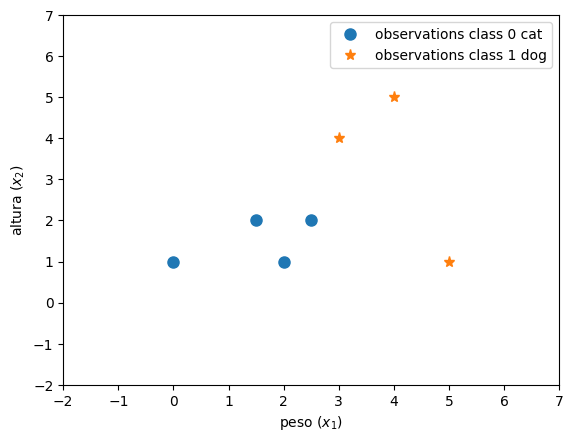

Es decir, buscamos una función en dos variables de la forma

$$ \begin{split} z = w_1\cdot x_1 + w_2 \cdot x_2 + b\\ y = \frac{1}{1 + \exp^{-z}} \end{split} $$

Lo reescribimos en forma matricial:

$$ w = \begin{bmatrix} w_1 \\ w_2 \end{bmatrix} $$

$$ x = \begin{bmatrix} x_1 \\ x_2 \end{bmatrix} $$

Así,

$$ \begin{split} z = x^T w + b\\ y = \frac{1}{1 + \exp^{-z}} \end{split} $$

[video not shown]

## Función de coste

Usando la entropía cruzada binaria, nuestra función de coste es:

$$L_{\mathrm{BCE}}(w_1, w_2, b) := - \sum_{i=1}^N \left( (1- y^{(i)}) \log(1- \hat{y}^{(i)}) + y^{(i)} \log (\hat{y}^{(i)}) \right).$$

[video not shown]

[video not shown]

## Ajuste del modelo

### Gradiente

Las derivadas parciales de la función de coste son: \begin{align*} \dfrac{\partial L_{\mathrm{BCE}}}{\partial w_1} (w_1, w_2, b) & = \sum_{i=1}^N \left( f(x_1^{(i)}, x_2^{(i)}) - y^{(i)} \right) x^{(i)}_1 \\ \dfrac{\partial L_{\mathrm{BCE}}}{\partial w_2} (w_1, w_2, b) & = \sum_{i=1}^N \left( f(x_1^{(i)}, x_2^{(i)}) - y^{(i)} \right) x^{(i)}_2 \\ \dfrac{\partial L_{\mathrm{BCE}}}{\partial b} (w_1, w_2, b) & = \sum_{i=1}^N \left( f(x_1^{(i)}, x_2^{(i)}) - y^{(i)} \right) \end{align*}

### Descenso del gradiente

Aplicamos el descenso del gradiente para encontrar los valores óptimos de los tres parámetros $w_1$, $w_2$ y $b$.

```
Obtained optimal parameters w=[[1.69941258]
 [0.91251503]] b = [[-7.0408672]] with associated loss 0.7265209609705992
```

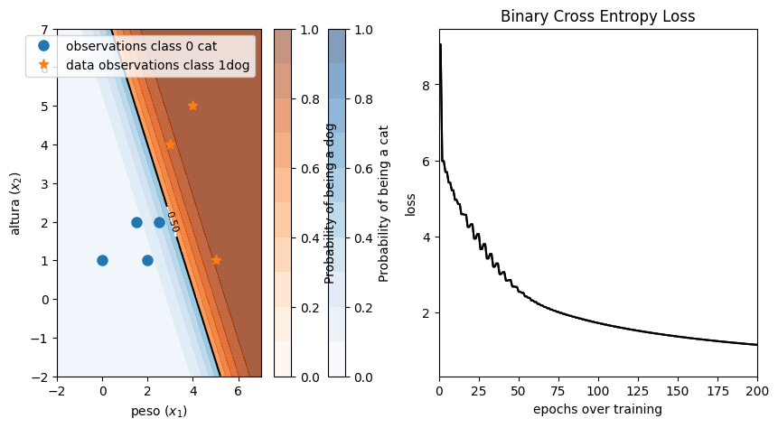

[video not shown]

# Frontera de decisión

Hay casos en los que que la regresión logística no es el algoritmo más adecuado. Esto se debe generalmente a cómo es la **frontera de decisión**.

### Definición

En problemas de clasificación, la **frontera de decisión** particiona el espacio de los atributos en las distintas regiones, correspondientes a las clases que asignará el modelo de clasificación.

La regresión logística es un modelo lineal, ya que la frontera de decisión que se obtiene está dada por hiperplanos.

### Ejemplos

#### Ejemplo real

Cada algoritmo crea una frontera de decisión distinta, y por lo tanto, clasificará los datos de forma distinta. Conocer la forma de la frontera de decisión de un algoritmo es importante para intuir si se ajustará bien a un conjunto específico de datos.

Para problemas con más de 2 atributos, las fronteras de decisión son hipersuperficies de dimensión $n-1$ en un espacio de $n$ dimensiones.

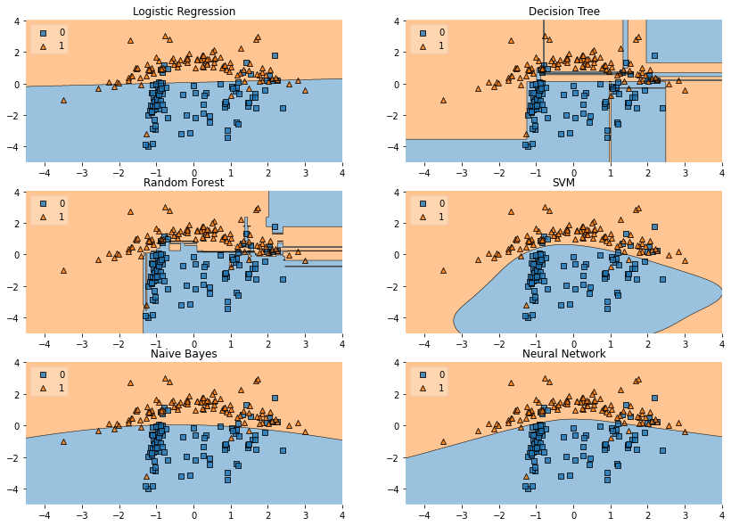

Todas las animaciones son del profesor Juan Maroñas.